# Pipeline Preparation

Emmanuel Miguel Gonzalez

# Pipeline Preparation

The PhytoOracle (PO) pipelines require the aforementioned GCP and GeoJSON files. Additionally, a Yet Another Markup Language (YAML) file is used by PO for automated, reproducible data processing. YAMLs are a form of a configuration file that can be used to define a series of arguments/flags. The details of the YAML files can be found on our [PhytoOracle Automation repository](https://github.com/phytooracle/automation/blob/main/docs/yaml.md).

## Editing YAML file

For each season, YAML files must be edited to correctly process data for the respective season.

Specifically, the following keys should be edited for each season:

- tags
  - pipeline
  - season
  - season_name
- workload_manager
  - manager_name
- paths
  - cyverse
    - input
      - necessary_files

Examples of YAMLs for each season can be found [here](https://github.com/phytooracle/automation/tree/main/yaml_files).

## Updating GitHub Repositories

### PhytoOracle Data

The season is defined by multiple keys, including name, start_date, end_date, flir_temp_units, and complete_field_dates (**Figure @ref(fig:phytooracledataplot)**).

Below are some details for each key:

- name: Season name, as it shows up on the CyVerse DataStore
- start_date: Date of planting
- end_date: Date of harvest
- flir_temp_units: Temperature units reported by thermal (FLIR) images
- complete_field_dates: List of RGB scan dates

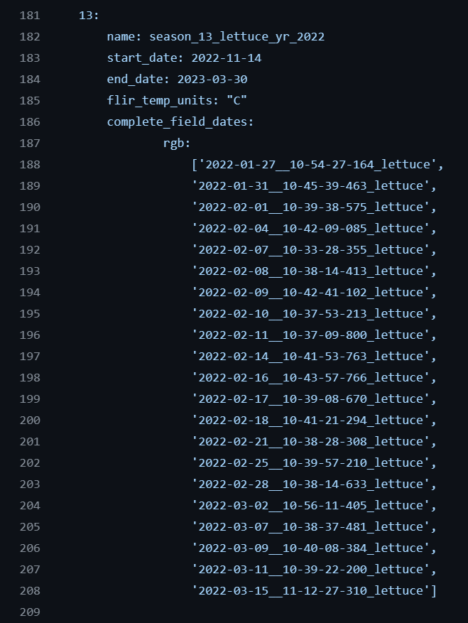

Section of the season_config_yaml variable in the phytooracle_data GitHub repository.

To get a list of RGB dates, use iRODS to ils the directory of the respective season (**Figure @ref(fig:ilsplot)**).

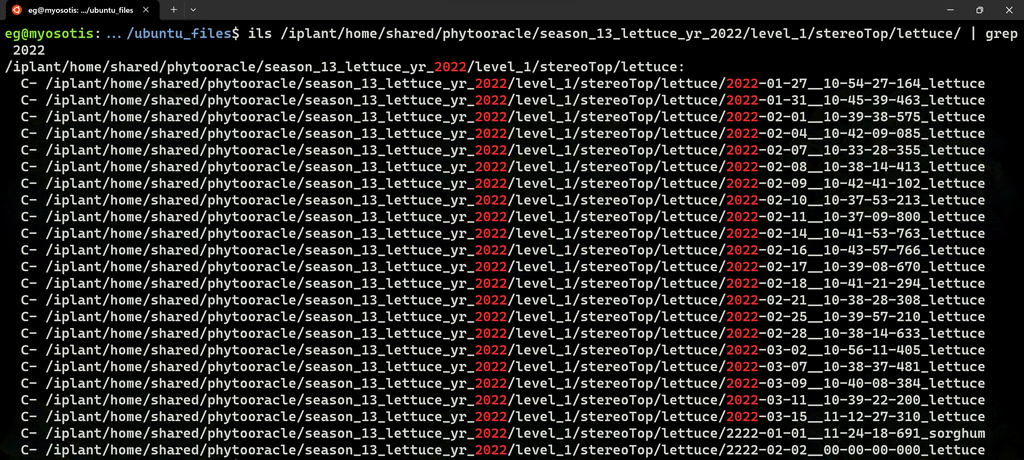

Getting RGB dates using iRODS.

### PhytoOracle Landmark Selection

The PhytoOracle 3d_landmark_selection contains the phytooracle_data repository. As such, the 3d_landmark_selection container must be rebuilt once the abovementioned changes have been made to [phytooracle_data repository](https://hub.docker.com/repository/docker/phytooracle/3d_landmark_selection/builds) and click on “Trigger” for the “latest” container (**Figure @ref(fig:containerplot)**).

[figure not shown]

Rebuilding the $3d_landmark_selection$ container on DockerHub.